# Working with Databases - Part II

Biostat 203B

Dr. Hua Zhou @ UCLA

Feb 10, 2022

## Introduction

In this lecture we will learn:

- Import data from bigish csv files (MIMIC-IV).
- Deposit data into an SQLite database.
- Query SQLite database.
- Transform in database and plot in R.

## Machine information

Load necessary R packages

```r
library(tidyverse)
library(DBI)
library(RSQLite)
library("dbplyr")
```

```bash
# display version of SQLite
sqlite3 --version
```

```
## 3.7.17 2013-05-20 00:56:22 118a3b35693b134d56ebd780123b7fd6f1497668
```

## CSV file

The `/mnt/mimiciv/1.0` folder on the teaching server contains the MIMIC-IV data. On my Mac, it’s at `/Users/huazhou/Documents/Box Sync/MIMIC/mimic-iv-1.0`.

Display content of MIMIC-IV data files:

```r
os <- sessionInfo()$running
if (str_detect(os, "Linux")) {
  mimic_path <- "/mnt/mimiciv/1.0"
} else if (str_detect(os, "macOS")) {
  mimic_path <- "/Users/huazhou/Documents/Box Sync/MIMIC/mimic-iv-1.0"
}
mimic_path
```

```
## [1] "/mnt/mimiciv/1.0"
```

```r
system(str_c("tree -s -L 2 ", shQuote(mimic_path)), intern = TRUE)
```

```
##  [1] "/mnt/mimiciv/1.0"
##  [2] "├── [       2356]  biostat-203b-2022winter-3fdc2392ac39.json"
##  [3] "├── [        439]  client_secret_34349235653-sidv2drmetcimi1fba4tj024aqth8qmr.apps.googleusercontent.com.json"
##  [4] "├── [       4096]  core"
##  [5] "│   ├── [   17208966]  admissions.csv.gz"
##  [6] "│   ├── [        606]  index.html"
##  [7] "│   ├── [    2955582]  patients.csv.gz"
##  [8] "│   └── [   53014503]  transfers.csv.gz"
##  [9] "├── [       4096]  hosp"
## [10] "│   ├── [     430049]  d_hcpcs.csv.gz"
## [11] "│   ├── [   29531152]  diagnoses_icd.csv.gz"
## [12] "│   ├── [     863239]  d_icd_diagnoses.csv.gz"
## [13] "│   ├── [     579998]  d_icd_procedures.csv.gz"
## [14] "│   ├── [      14898]  d_labitems.csv.gz"
## [15] "│   ├── [   11684062]  drgcodes.csv.gz"
```

[output cut: 28 more lines]

## Read CSVs and deposit to an SQLite database

Here, we will import only one csv file `icustays.csv.gz` for demonstration purpose. Motivated students can write a bash script for loading all MIMIC-IV data files into a SQLite database and contribute to https://github.com/MIT-LCP/mimic-code.

Create an empty database file `mimiciv.sqlite`:

```r
cmd <- 'touch mimiciv.sqlite'
system(cmd, intern = TRUE)
```

```
## character(0)
```

Deposit the `icu/icustatys.csv.gz` file:

```r
# delete icustays table if exists
cmd <- "sqlite3 mimiciv.sqlite 'DROP TABLE IF EXISTS icustays;'"
system(cmd, intern = TRUE)
```

```
## character(0)
```

Create an empty `icustays` table with data types. Because SQLite does not support date-time data type (https://www.sqlite.org/datatype3.html), we store `intime` and `outtime` as TEXT.

```r
cmd <- "sqlite3 mimiciv.sqlite 'CREATE TABLE icustays (subject_id INTEGER, hadm_id INTEGER, stay_id INTEGER, first_careunit TEXT, last_careunit TEXT, intime TEXT, outtime TEXT, los REAL)'"
system(cmd, intern = TRUE)
```

```
## character(0)
```

```r
csvfile <- str_c(mimic_path, "/icu/icustays.csv.gz")
cmd <- str_c(
  "zcat < ",
  shQuote(csvfile),
  " | tail -n +2 | ",
  "sqlite3 mimiciv.sqlite -csv ",
  "'.import /dev/stdin icustays'"
)
cmd
```

```
## [1] "zcat < '/mnt/mimiciv/1.0/icu/icustays.csv.gz' | tail -n +2 | sqlite3 mimiciv.sqlite -csv '.import /dev/stdin icustays'"
```

Execute the bash command:

```r
system(cmd, intern = TRUE)
```

```
## character(0)
```

## Read data from database

Connect to the database `mimiciii.sqlite` and list the tables:

```r
con <- dbConnect(RSQLite::SQLite(),
                 dbname = "./mimiciv.sqlite"
                 )
dbListTables(con)
```

```
## [1] "icustays"
```

Read the table `icustays`:

```r
icustays_tble <- tbl(con, "icustays") %>%
  print(width = Inf)
```

```
## # Source:   table<icustays> [?? x 8]
## # Database: sqlite 3.37.0
## #   [/home/huazhou/203b-2022winter/slides/12-dbplyr/mimiciv.sqlite]
##    subject_id  hadm_id  stay_id first_careunit
##         <int>    <int>    <int> <chr>
##  1   17867402 24528534 31793211 Trauma SICU (TSICU)
##  2   14435996 28960964 31983544 Trauma SICU (TSICU)
##  3   17609946 27385897 33183475 Trauma SICU (TSICU)
##  4   18966770 23483021 34131444 Trauma SICU (TSICU)
##  5   12776735 20817525 34547665 Neuro Stepdown
##  6   10215159 24283593 34569476 Trauma SICU (TSICU)
##  7   14489052 26516390 35056286 Trauma SICU (TSICU)
##  8   15914763 28906020 36909804 Trauma SICU (TSICU)
##  9   16256226 20013290 39289362 Neuro Stepdown
## 10   19194449 21641999 39387567 Coronary Care Unit (CCU)
##    last_careunit            intime              outtime               los
##    <chr>                    <chr>               <chr>               <dbl>
##  1 Trauma SICU (TSICU)      2154-03-03 04:11:00 2154-03-04 18:16:56 1.59
##  2 Trauma SICU (TSICU)      2150-06-19 17:57:00 2150-06-22 18:33:54 3.03
##  3 Trauma SICU (TSICU)      2138-02-05 18:54:00 2138-02-15 12:42:05 9.74
##  4 Trauma SICU (TSICU)      2123-10-25 10:35:00 2123-10-25 18:59:47 0.351
##  5 Neuro Stepdown           2200-07-12 00:33:00 2200-07-13 16:44:40 1.67
##  6 Trauma SICU (TSICU)      2124-09-20 15:05:29 2124-09-21 22:06:58 1.29
##  7 Trauma SICU (TSICU)      2118-10-26 10:33:56 2118-10-26 20:28:10 0.413
##  8 Trauma SICU (TSICU)      2176-12-14 12:00:00 2176-12-17 11:47:01 2.99
##  9 Neuro Stepdown           2150-12-20 16:09:08 2150-12-21 14:58:40 0.951
## 10 Coronary Care Unit (CCU) 2123-11-12 02:53:35 2123-11-12 13:52:03 0.457
## # … with more rows
```

How many rows?

```r
icustays_tble %>%
  show_query() %>%
  summarise(n = n())
```

```
## <SQL>
## SELECT *
## FROM `icustays`
```

```
## # Source:   lazy query [?? x 1]
## # Database: sqlite 3.37.0
## #   [/home/huazhou/203b-2022winter/slides/12-dbplyr/mimiciv.sqlite]
##       n
##   <int>
## 1 76540
```

## Use dplyr with SQLite

Keep the first ICU stay for each patient:

```r
icustays_subset <- icustays_tble %>%
  # first ICU stay of each unique `subject_id`
  group_by(subject_id) %>%
  slice_min(intime) %>%
  ungroup() %>%
  # arrange(intime, .by_group = TRUE) %>%
  # slice_head(n = 1) %>%
  # left_join(icustays_tble, by = c("subject_id", "intime")) %>%
  show_query() %>%
  print(width = Inf)
```

```
## <SQL>
## SELECT `subject_id`, `hadm_id`, `stay_id`, `first_careunit`, `last_careunit`, `intime`, `outtime`, `los`
## FROM (SELECT `subject_id`, `hadm_id`, `stay_id`, `first_careunit`, `last_careunit`, `intime`, `outtime`, `los`, RANK() OVER (PARTITION BY `subject_id` ORDER BY `intime`) AS `q01`
## FROM `icustays`)
## WHERE (`q01` <= 1)
## # Source:     lazy query [?? x 8]
## # Database:   sqlite 3.37.0
## #   [/home/huazhou/203b-2022winter/slides/12-dbplyr/mimiciv.sqlite]
## # Ordered by: intime
##    subject_id  hadm_id  stay_id first_careunit
##         <int>    <int>    <int> <chr>
##  1   10000032 29079034 39553978 Medical Intensive Care Unit (MICU)
##  2   10000980 26913865 39765666 Medical Intensive Care Unit (MICU)
##  3   10001217 24597018 37067082 Surgical Intensive Care Unit (SICU)
##  4   10001725 25563031 31205490 Medical/Surgical Intensive Care Unit (MICU/SICU)
##  5   10001884 26184834 37510196 Medical Intensive Care Unit (MICU)
##  6   10002013 23581541 39060235 Cardiac Vascular Intensive Care Unit (CVICU)
##  7   10002155 23822395 33685454 Coronary Care Unit (CCU)
##  8   10002223 22494570 39638202 Trauma SICU (TSICU)
##  9   10002348 22725460 32610785 Neuro Intermediate
## 10   10002428 28662225 33987268 Medical Intensive Care Unit (MICU)
##    last_careunit                                    intime
##    <chr>                                            <chr>
##  1 Medical Intensive Care Unit (MICU)               2180-07-23 14:00:00
##  2 Medical Intensive Care Unit (MICU)               2189-06-27 08:42:00
##  3 Surgical Intensive Care Unit (SICU)              2157-11-20 19:18:02
##  4 Medical/Surgical Intensive Care Unit (MICU/SICU) 2110-04-11 15:52:22
##  5 Medical Intensive Care Unit (MICU)               2131-01-11 04:20:05
##  6 Cardiac Vascular Intensive Care Unit (CVICU)     2160-05-18 10:00:53
##  7 Coronary Care Unit (CCU)                         2129-08-04 12:45:00
##  8 Trauma SICU (TSICU)                              2158-01-15 08:01:49
##  9 Neuro Intermediate                               2112-11-30 23:24:00
## 10 Medical Intensive Care Unit (MICU)               2156-04-12 16:24:18
##    outtime               los
##    <chr>               <dbl>
##  1 2180-07-23 23:50:47 0.410
##  2 2189-06-27 20:38:27 0.498
##  3 2157-11-21 22:08:00 1.12
##  4 2110-04-12 23:59:56 1.34
##  5 2131-01-20 08:27:30 9.17
##  6 2160-05-19 17:33:33 1.31
##  7 2129-08-10 17:02:38 6.18
##  8 2158-01-16 15:19:24 1.30
##  9 2112-12-10 18:25:13 9.79
## 10 2156-04-17 15:57:08 4.98
## # … with more rows
```

How many rows in `icustays_subset`?

```r
icustays_subset %>%
  show_query() %>%
  summarise(n = n())
```

```
## <SQL>
## SELECT `subject_id`, `hadm_id`, `stay_id`, `first_careunit`, `last_careunit`, `intime`, `outtime`, `los`
## FROM (SELECT `subject_id`, `hadm_id`, `stay_id`, `first_careunit`, `last_careunit`, `intime`, `outtime`, `los`, RANK() OVER (PARTITION BY `subject_id` ORDER BY `intime`) AS `q01`
## FROM `icustays`)
## WHERE (`q01` <= 1)
```

```
## # Source:   lazy query [?? x 1]
## # Database: sqlite 3.37.0
## #   [/home/huazhou/203b-2022winter/slides/12-dbplyr/mimiciv.sqlite]
##       n
##   <int>
## 1 53150
```

## SQL query

`show_query` usefully shows the SQL query translated from dplyr query.

```r
class(icustays_subset)
```

```
## [1] "tbl_SQLiteConnection" "tbl_dbi"              "tbl_sql"
## [4] "tbl_lazy"             "tbl"
```

```r
show_query(icustays_subset)
```

```
## <SQL>
## SELECT `subject_id`, `hadm_id`, `stay_id`, `first_careunit`, `last_careunit`, `intime`, `outtime`, `los`
## FROM (SELECT `subject_id`, `hadm_id`, `stay_id`, `first_careunit`, `last_careunit`, `intime`, `outtime`, `los`, RANK() OVER (PARTITION BY `subject_id` ORDER BY `intime`) AS `q01`
## FROM `icustays`)
## WHERE (`q01` <= 1)
```

## Transform in database, plot in R

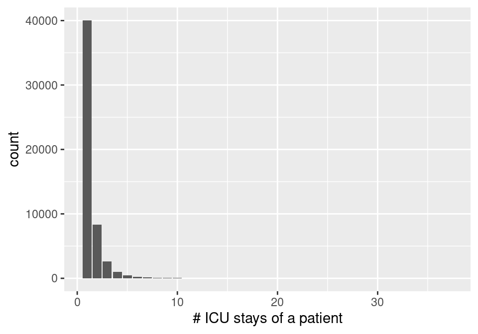

```r
icustays_tble %>%
  group_by(subject_id) %>%
  summarise(n = n()) %>%
  ggplot() +
  geom_bar(mapping = aes(x = n)) +
  labs(x = "# ICU stays of a patient")
```

## SQL translation

dbplyr package (a dplyr backend for databases) has a function, `translate_sql`, that lets you experiment with how R functions are translated to SQL:

```r
translate_sql(x == 1 & (y < 2 | z > 3))
```

```
## <SQL> `x` = 1.0 AND (`y` < 2.0 OR `z` > 3.0)
```

```r
translate_sql(x ^ 2 < 10)
```

```
## <SQL> POWER(`x`, 2.0) < 10.0
```

```r
translate_sql(x %% 2 == 10)
```

```
## <SQL> `x` % 2.0 = 10.0
```

```r
translate_sql(paste(x, y))
```

```
## <SQL> CONCAT_WS(' ', `x`, `y`)
```

```r
translate_sql(mean(x))
```

```
## <SQL> AVG(`x`) OVER ()
```

```r
translate_sql(mean(x, na.rm = TRUE))
```

```
## <SQL> AVG(`x`) OVER ()
```

## Timings

Let’s compare the timings of dplyr (in-memory) and dbplyr (on disk database).

- dplyr using tibble:

```r
csvfile <- str_c(mimic_path, "/icu/icustays.csv.gz")
icustays_tibble <- read_csv(csvfile)
timing_tibble <- system.time(
  icustays_tibble %>%
    group_by(subject_id) %>%
    summarize(n = n())
)
timing_tibble
```

```
##    user  system elapsed
##   1.442   0.001   1.444
```

- dbplyr using SQLite:

```r
icustays_sql <- tbl(con, "icustays")
timing_sql <- system.time(
  icustays_sql %>%
    group_by(subject_id) %>%
    summarize(n = n())
)
timing_sql
```

```
##    user  system elapsed
##   0.002   0.000   0.002
```

SQLite (0.002 seconds) was much faster than tibble (1.444 seconds). But SQLite is disk-based, while the tibble is in memory. Why is the discrepancy?

## Laziness

dplyr/dbplyr uses lazy evaluation as much as possible, particularly when working with non-local backends.

- When building a query, often we don’t want the entire table. We want just enough to check if our query is working.
- Since we would prefer to run one complex query over many simple queries, laziness allows for verbs to be strung together.
- Therefore, by default dbplyr
  - won’t connect and query the database until absolutely necessary (e.g. show output),
  - and unless explicitly told to, will only query a handful of rows to give a sense of what the result will look like

```r
icustays_sql %>%
  group_by(subject_id) %>%
  summarize(n = n())
```

```
## # Source:   lazy query [?? x 2]
## # Database: sqlite 3.37.0
## #   [/home/huazhou/203b-2022winter/slides/12-dbplyr/mimiciv.sqlite]
##    subject_id     n
##         <int> <int>
##  1   10000032     1
##  2   10000980     1
##  3   10001217     2
##  4   10001725     1
##  5   10001884     1
##  6   10002013     1
##  7   10002155     3
##  8   10002223     1
##  9   10002348     1
## 10   10002428     4
## # … with more rows
```

## Full query

To force a full query and return a complete table it is necessary to use the `collect` function.

```r
system.time(
  icustays_sql %>%
    group_by(subject_id) %>%
    summarize(n = n()) %>%
    collect()
)
```

```
##    user  system elapsed
##   0.124   0.028   0.153
```

## Old ggplot2 doesn’t do ``Transform in database, plot in R”

Earlier we see dbplyr connects with ggplot2 (v3.3.5) seamlessly. Remember ggplot2 needs to `collect` the query results for plotting.

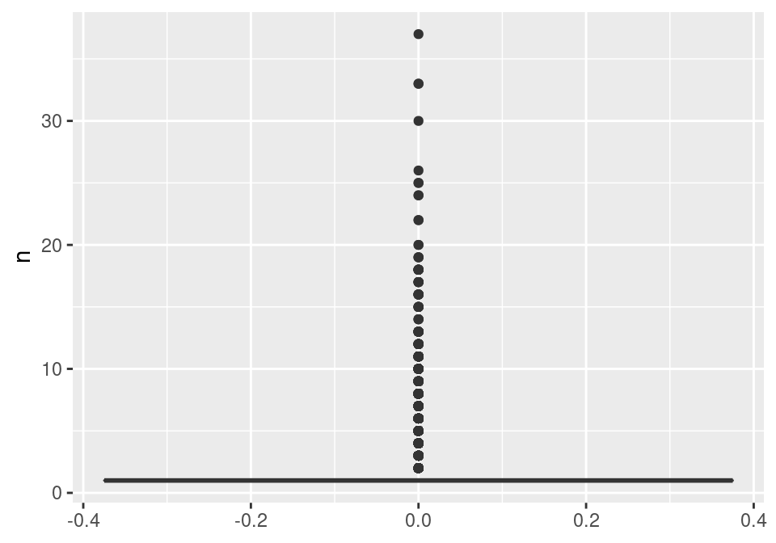

```r
icustays_sql %>%
  count(subject_id) %>%
  ggplot() +
  geom_boxplot(mapping = aes(y = n))
```

Older version of ggplot2, e.g., v2.2.1, will output error. This is because ggplot2 needed to compute the count per bin by going through all the rows. But here `icustays_sql` is just a pointer to the SQLite table. We had to use the **transform in database, plot in R** strategy.

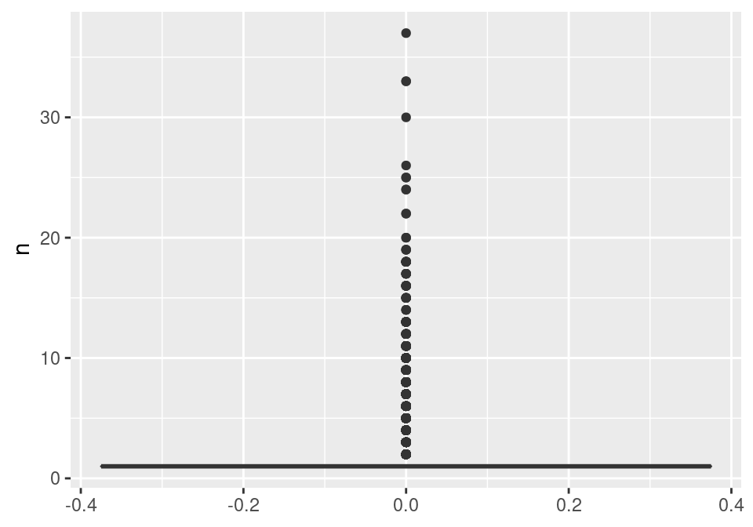

```r
icustays_sql %>%
  count(subject_id) %>%
  collect() %>%
  ggplot() +
  geom_boxplot(mapping = aes(y = n))
```

## Close connection to database

```r
dbDisconnect(con)
```